# Week11 Assignment

Sophie Kim

April 28, 2016

# 1. Narrow and broad heritability, sans lm()

Using the data in ParentChildHeight.txt, let’s estimate the narrow sense heritability of height. Without using the function lm() (but you may use any of the other built in R functions):

Compute the intercept and the slope of the regression line.

```r
pcdata <- read.table("ParentChildHeight.txt", header = TRUE)

parent <- c()

n <- length(pcdata$parent1)

for (i in 1:n){
  parent[i] <- (pcdata[i,1] + pcdata[i,2])/2
}

child <- pcdata$child

slope <- cov(parent, child) / var(parent)

intercept <- mean(child) - slope * mean(parent)
```

Calculate the residuals, so one for for each observation in the dataset.

```r
residual <- c()

for (i in 1:n){
  residual[i] <- child[i] - (slope * parent[i] + intercept)
}

head(residual)
```

```
## [1] -3.3170747  0.5930064  2.9614472 -0.9812095 -1.6093111  3.7857025
```

Compute the residual mean square (MSresidual).

```r
MSresidual <- sum(residual^2) / (n - 2)
MSresidual
```

```
## [1] 8.269404
```

Compute the standard error of the slope.

```r
SSxx <- 0
for (i in 1:n){
  SSxx <- SSxx + (parent[i] - mean(parent))^2
}

SEreg <- sqrt(MSresidual) / sqrt(SSxx)
SEreg
```

```
## [1] 0.0366661
```

Compute $R^2$.

```r
SSyy <- 0
SSres <- 0

for (i in 1:n) {
  SSyy <- SSyy + (child[i] - mean(child))^2
  SSres <- SSres + (child[i] - (slope * parent[i] + intercept))^2
}

Rsquared <- 1- (SSres / SSyy)
Rsquared
```

```
## [1] 0.8209208
```

> > 1.1 Use a t-test to test significance

Calculate the value of the t-statistic and its degrees of freedom.

```r
b <- slope
SEb <- sqrt(MSresidual/SSxx)
tstat <- b / SEb
tstat
```

```
## [1] 21.19538
```

Calculate the corresponding p-value and interpret the result.

```r
df = n - 2
1 - pt(tstat, df)
```

```
## [1] 0
```

> > 1.2 Perform an ANOVA to evaluate the slope of the regression line

Calculate the ratio of the residual mean square of the data to the residual mean square of the regression.

```r
MSreg <- 0

for (i in 1:n) {
  MSreg <- MSreg + (child[i] - mean(child))^2
}

MSregression <- MSreg / (n-2)

Fstatistic <- MSresidual / MSregression
Fstatistic
```

```
## [1] 0.1790792
```

Evaluate the significance of this result by comparing it to the F-statistic distribution, by calculating the p-value.

```r
pval <- 1 - pf(Fstatistic, n-2, n-2)
pval
```

```
## [1] 1
```

Compare your calculations to values calculated using the function lm(). Try wrapping in summary().

```r
summary(lm(child ~ parent))
```

```
##
## Call:
## lm(formula = child ~ parent)
##
## Residuals:
##     Min      1Q  Median      3Q     Max
## -7.8158 -1.5165  0.2212  1.7059  6.9926
##
## Coefficients:
##             Estimate Std. Error t value Pr(>|t|)
## (Intercept) 38.80718    6.18984   6.269 9.77e-09 ***
## parent       0.77715    0.03667  21.195  < 2e-16 ***
## ---
## Signif. codes:  0 '***' 0.001 '**' 0.01 '*' 0.05 '.' 0.1 ' ' 1
##
## Residual standard error: 2.876 on 98 degrees of freedom
## Multiple R-squared:  0.8209, Adjusted R-squared:  0.8191
## F-statistic: 449.2 on 1 and 98 DF,  p-value: < 2.2e-16
```

Plot the data and regression line.

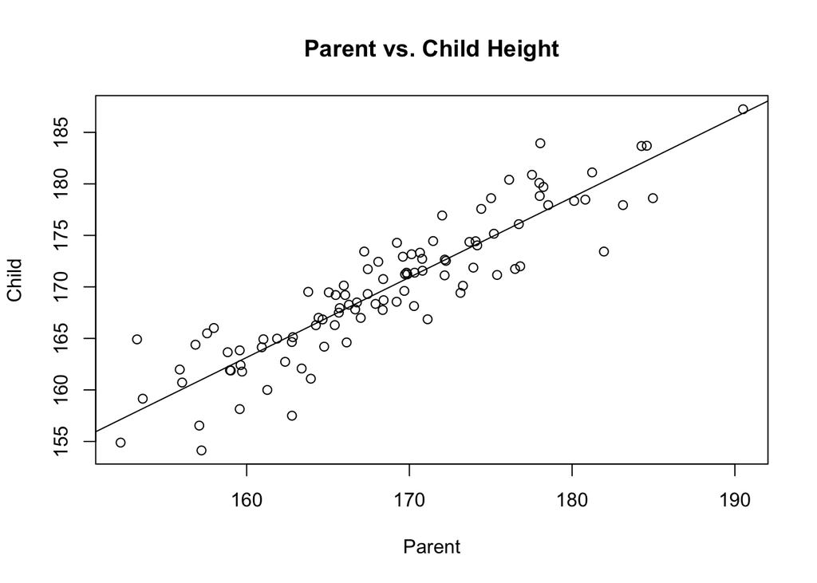

```r
plot(parent, child, main = "Parent vs. Child Height", xlab = "Parent", ylab = "Child")
abline(intercept, slope)
```

What is the narrow-sense heritability of height?

```r
h <- slope
h
```

```
## [1] 0.7771519
```

# 2. Using lm()

The file genesMelt.txt contains time series data for the expression of four transcripts. The data is organized so that each row is an observation of a certain gene at a certain time, and we observe a certain value.

Perform least squares regression for each gene’s expression explained by time.

```r
gdata <- read.table("genes.txt", header = T)

time <- gdata$time
gene1 <- gdata$gene1
gene2 <- gdata$gene2
gene3 <- gdata$gene3
gene4 <- gdata$gene4

summary(lm(gene1 ~ time))
```

```
##
## Call:
## lm(formula = gene1 ~ time)
##
## Residuals:
##        1        2        3        4        5
## -0.05405 -2.25676  3.54054 -0.66216 -0.56757
##
## Coefficients:
##             Estimate Std. Error t value Pr(>|t|)
## (Intercept)   3.0541     1.7975   1.699   0.1879
## time          1.6014     0.3218   4.976   0.0156 *
## ---
## Signif. codes:  0 '***' 0.001 '**' 0.01 '*' 0.05 '.' 0.1 ' ' 1
##
## Residual standard error: 2.476 on 3 degrees of freedom
## Multiple R-squared:  0.8919, Adjusted R-squared:  0.8559
## F-statistic: 24.76 on 1 and 3 DF,  p-value: 0.0156
```

```r
summary(lm(gene2 ~ time))
```

```
##
## Call:
## lm(formula = gene2 ~ time)
##
## Residuals:
##      1      2      3      4      5
##  5.757 -4.405 -4.568  1.270  1.946
##
## Coefficients:
##             Estimate Std. Error t value Pr(>|t|)
## (Intercept)   2.2432     3.7209   0.603   0.5891
## time          1.5811     0.6661   2.373   0.0982 .
## ---
## Signif. codes:  0 '***' 0.001 '**' 0.01 '*' 0.05 '.' 0.1 ' ' 1
##
## Residual standard error: 5.125 on 3 degrees of freedom
## Multiple R-squared:  0.6525, Adjusted R-squared:  0.5367
## F-statistic: 5.633 on 1 and 3 DF,  p-value: 0.0982
```

```r
summary(lm(gene3 ~ time))
```

```
##
## Call:
## lm(formula = gene3 ~ time)
##
## Residuals:
##       1       2       3       4       5
## -0.4797  0.7838 -0.4527  0.3108 -0.1622
##
## Coefficients:
##             Estimate Std. Error t value Pr(>|t|)
## (Intercept)  5.47973    0.45381  12.075  0.00122 **
## time         0.36824    0.08125   4.532  0.02010 *
## ---
## Signif. codes:  0 '***' 0.001 '**' 0.01 '*' 0.05 '.' 0.1 ' ' 1
##
## Residual standard error: 0.6251 on 3 degrees of freedom
## Multiple R-squared:  0.8726, Adjusted R-squared:  0.8301
## F-statistic: 20.54 on 1 and 3 DF,  p-value: 0.0201
```

```r
summary(lm(gene4 ~ time))
```

```
##
## Call:
## lm(formula = gene4 ~ time)
##
## Residuals:
##        1        2        3        4        5
##  0.09459  1.32432 -2.44595  0.78378  0.24324
##
## Coefficients:
##             Estimate Std. Error t value Pr(>|t|)
## (Intercept)   4.9054     1.2161   4.034   0.0274 *
## time          0.3851     0.2177   1.769   0.1751
## ---
## Signif. codes:  0 '***' 0.001 '**' 0.01 '*' 0.05 '.' 0.1 ' ' 1
##
## Residual standard error: 1.675 on 3 degrees of freedom
## Multiple R-squared:  0.5105, Adjusted R-squared:  0.3474
## F-statistic: 3.129 on 1 and 3 DF,  p-value: 0.1751
```

– Gene1: intecept = 3.0541, slope = 1.6014, significance of the regression slope: 0.0156

– Gene2: intecept = 2.2432, slope = 1.5811, significance of the regression slope: 0.0982

– Gene3: intecept = 5.47973, slope = 0.36824, significance of the regression slope: 0.0201

– Gene4: intecept = 4.9054, slope = 0.3851, significance of the regression slope: 0.1751

Plot the data and regression line for each gene.

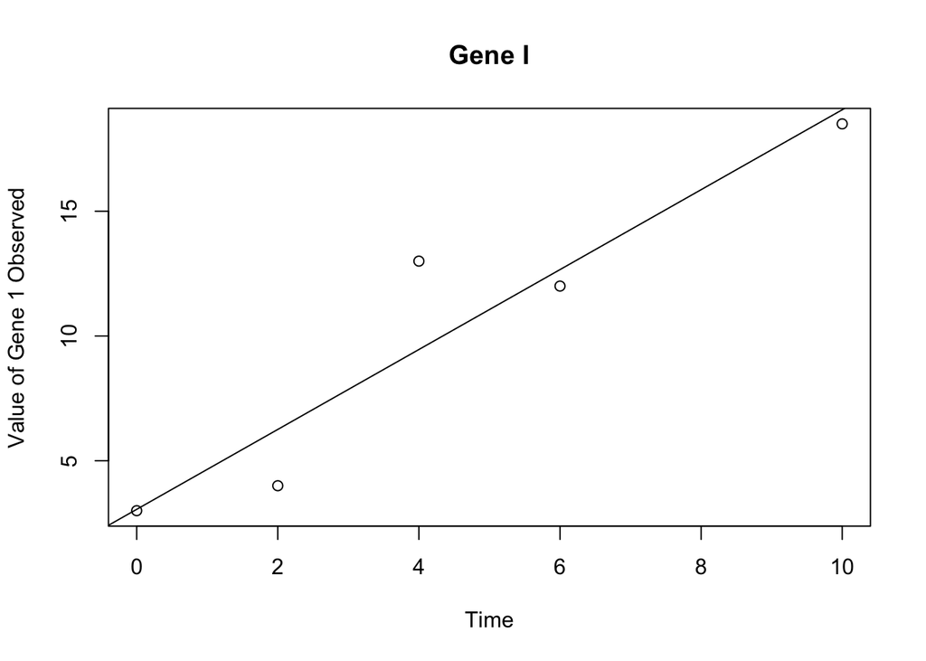

```r
plot(time, gene1, main = "Gene I", xlab = "Time", ylab = "Value of Gene 1 Observed")
int1 <- 3.0541
slope1 <- 1.6014
abline(int1, slope1)
```

[figure not shown]

```r
plot(time, gene1, main = "Gene II", xlab = "Time", ylab = "Value of Gene 2 Observed")
int2 <- 2.2432
slope2 <- 1.5811
abline(int2, slope2)
```

[figure not shown]

```r
plot(time, gene1, main = "Gene III", xlab = "Time", ylab = "Value of Gene 3 Observed")
int3 <- 5.47973
slope3 <- 0.36824
abline(int3, slope3)
```

[figure not shown]

```r
plot(time, gene1, main = "Gene IV", xlab = "Time", ylab = "Value of Gene 4 Observed")
int4 <- 4.9054
slope4 <- 0.3851
abline(int4, slope4)
```

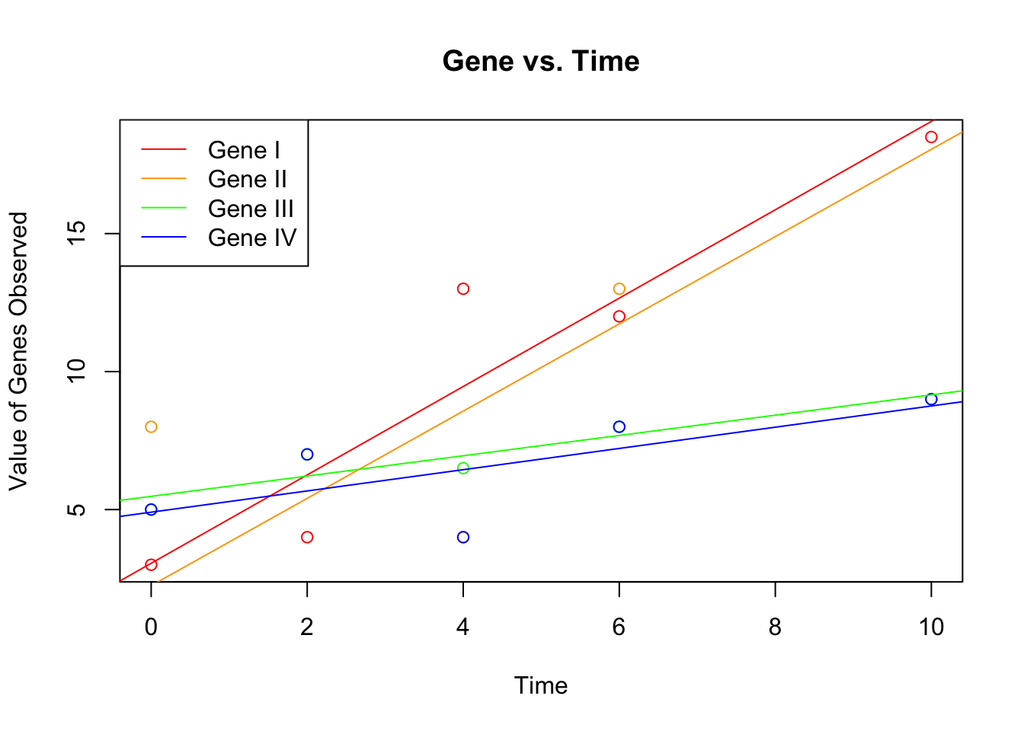

```r
plot(time, gene1, main = "Gene vs. Time", xlab = "Time", ylab = "Value of Genes Observed", col = "red")

points(time, gene2, col = "orange")
points(time, gene3, col = "green")
points(time, gene4, col = "blue")

abline(int1, slope1, col = "red")
abline(int2, slope2, col = "orange")
abline(int3, slope3, col = "green")
abline(int4, slope4, col = "blue")

legend("topleft", c("Gene I","Gene II", "Gene III", "Gene IV"), lty = c(1, 1), lwd = c(1, 1), col=c("red", "orange", "green", "blue"))
```